# Visualización en el espacio - EM

## 2.8 De PAY_3

En esta sección se cruza `PAY_3` (estado de pago del cliente en julio de 2005, convertida a factor) contra las mismas variables numéricas, siguiendo la misma lógica de las secciones anteriores de `PAY`.

Se cruza `LIMIT_BAL` contra `PAY_3`, para comparar el monto de crédito otorgado según el estado de pago de julio de 2005.

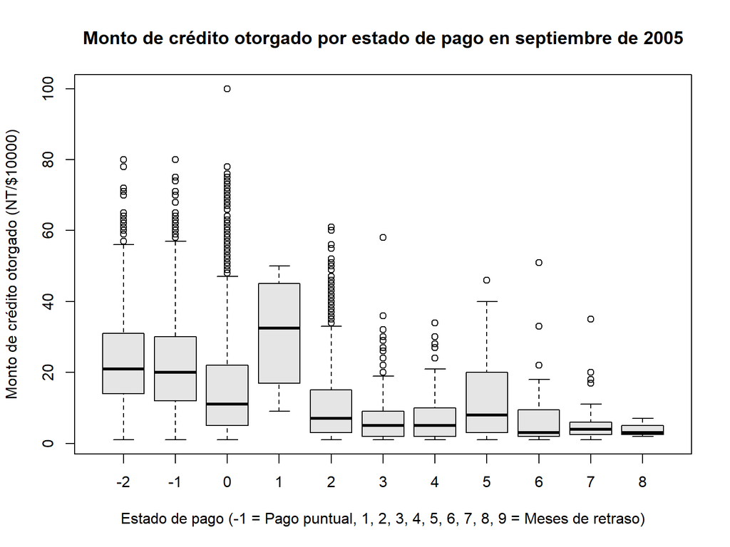

```r
boxplot(LIMIT_BAL/10000 ~ PAY_3, data = datos_credit_visu,
        main = "Monto de crédito otorgado por estado de pago en septiembre de 2005",
        xlab = "Estado de pago (-1 = Pago puntual, 1, 2, 3, 4, 5, 6, 7, 8, 9 = Meses de retraso)", ylab = "Monto de crédito otorgado (NT/$10000)",
        col = "grey90")
```

Se cruza `AGE` contra `PAY_3`, para observar si la edad se relaciona con el estado de pago de julio de 2005.

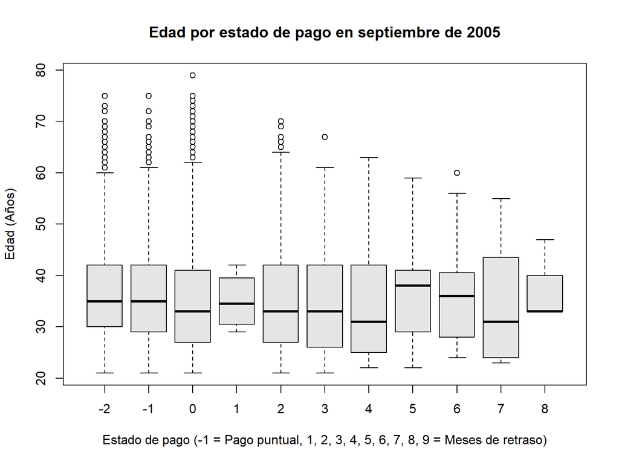

```r
boxplot(AGE ~ PAY_3, data = datos_credit_visu,
        main = "Edad por estado de pago en septiembre de 2005",
        xlab = "Estado de pago (-1 = Pago puntual, 1, 2, 3, 4, 5, 6, 7, 8, 9 = Meses de retraso)", ylab = "Edad (Años)",
        col = "grey90")
```

Se cruzan `BILL_AMT1` a `BILL_AMT6` contra `PAY_3`, generando un boxplot por mes para comparar el monto del estado de cuenta según el estado de pago de julio de 2005.

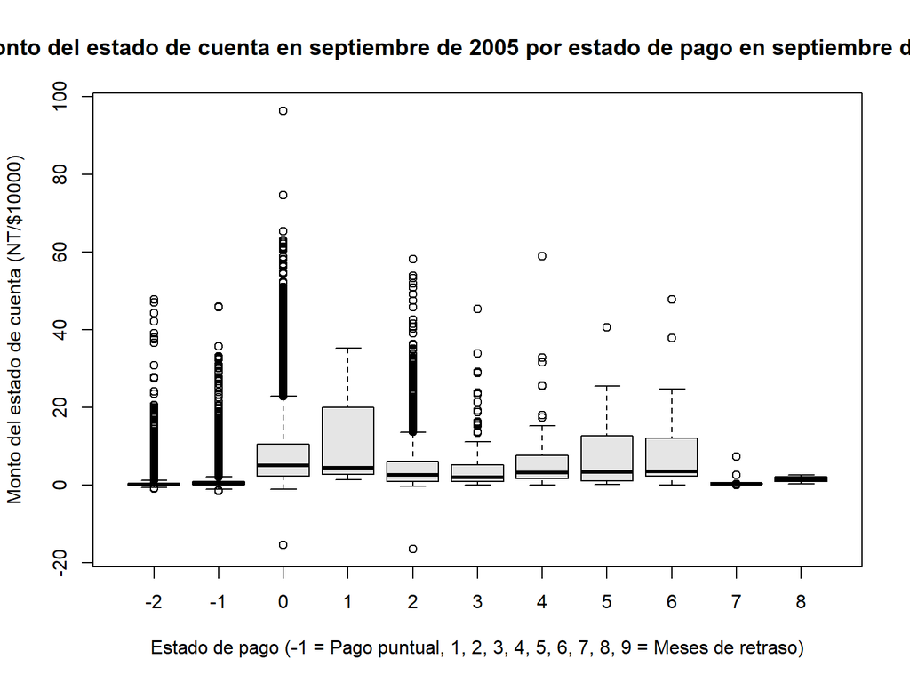

```r
boxplot(BILL_AMT1/10000 ~ PAY_3, data = datos_credit_visu,
        main = "Monto del estado de cuenta en septiembre de 2005 por estado de pago en septiembre de 2005",
        xlab = "Estado de pago (-1 = Pago puntual, 1, 2, 3, 4, 5, 6, 7, 8, 9 = Meses de retraso)", ylab = "Monto del estado de cuenta (NT/$10000)",
        col = "grey90")
```

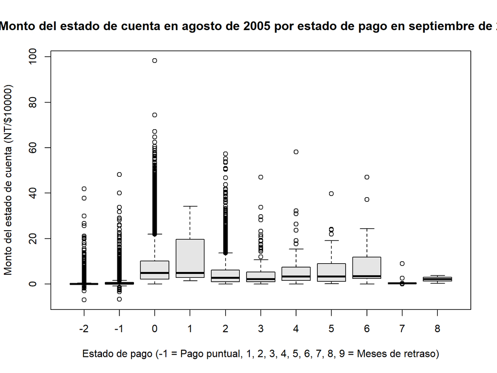

```r
boxplot(BILL_AMT2/10000 ~ PAY_3, data = datos_credit_visu,
        main = "Monto del estado de cuenta en agosto de 2005 por estado de pago en septiembre de 2005",
        xlab = "Estado de pago (-1 = Pago puntual, 1, 2, 3, 4, 5, 6, 7, 8, 9 = Meses de retraso)", ylab = "Monto del estado de cuenta (NT/$10000)",
        col = "grey90")
```

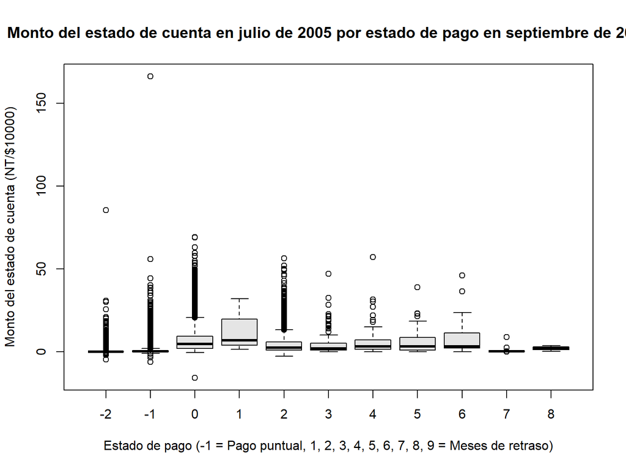

```r
boxplot(BILL_AMT3/10000 ~ PAY_3, data = datos_credit_visu,
        main = "Monto del estado de cuenta en julio de 2005 por estado de pago en septiembre de 2005",
        xlab = "Estado de pago (-1 = Pago puntual, 1, 2, 3, 4, 5, 6, 7, 8, 9 = Meses de retraso)", ylab = "Monto del estado de cuenta (NT/$10000)",
        col = "grey90")
```

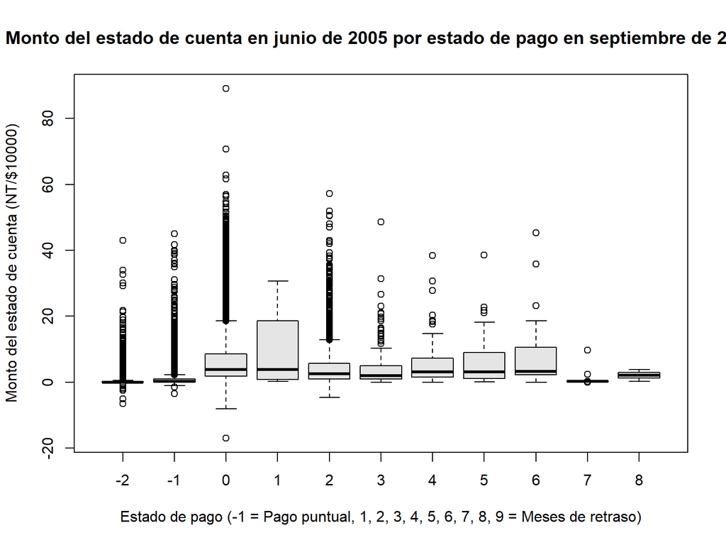

```r
boxplot(BILL_AMT4/10000 ~ PAY_3, data = datos_credit_visu,
        main = "Monto del estado de cuenta en junio de 2005 por estado de pago en septiembre de 2005",
        xlab = "Estado de pago (-1 = Pago puntual, 1, 2, 3, 4, 5, 6, 7, 8, 9 = Meses de retraso)", ylab = "Monto del estado de cuenta (NT/$10000)",
        col = "grey90")
```

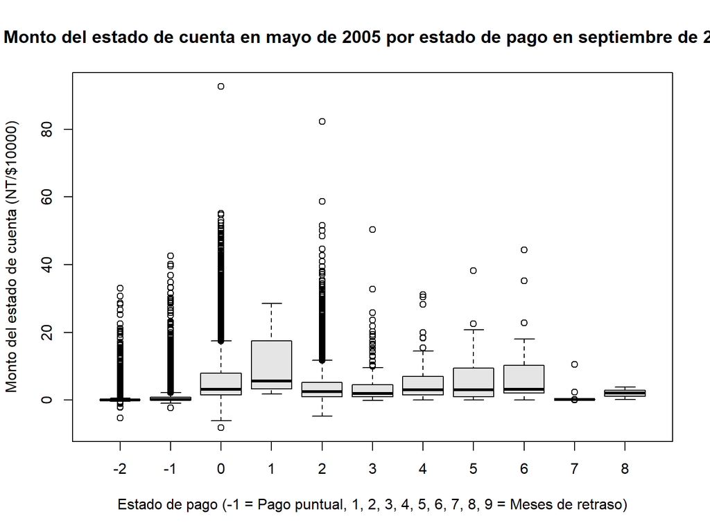

```r
boxplot(BILL_AMT5/10000 ~ PAY_3, data = datos_credit_visu,
        main = "Monto del estado de cuenta en mayo de 2005 por estado de pago en septiembre de 2005",
        xlab = "Estado de pago (-1 = Pago puntual, 1, 2, 3, 4, 5, 6, 7, 8, 9 = Meses de retraso)", ylab = "Monto del estado de cuenta (NT/$10000)",
        col = "grey90")
```

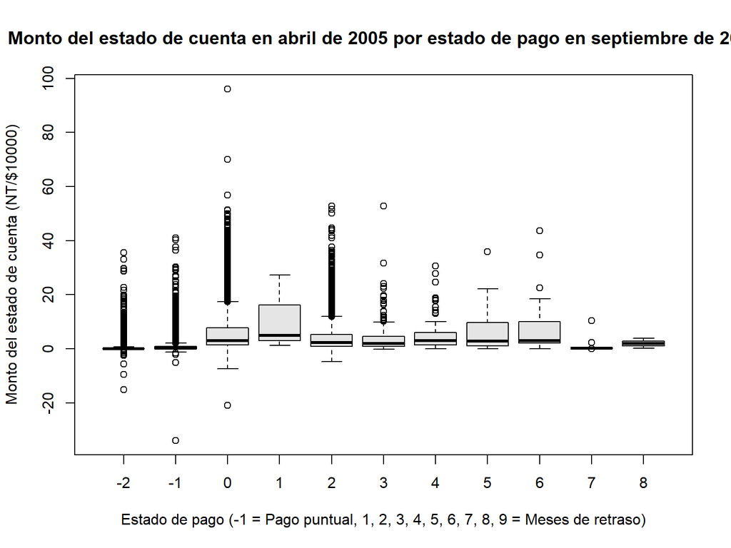

```r
boxplot(BILL_AMT6/10000 ~ PAY_3, data = datos_credit_visu,
        main = "Monto del estado de cuenta en abril de 2005 por estado de pago en septiembre de 2005",
        xlab = "Estado de pago (-1 = Pago puntual, 1, 2, 3, 4, 5, 6, 7, 8, 9 = Meses de retraso)", ylab = "Monto del estado de cuenta (NT/$10000)",
        col = "grey90")
```

Se cruzan `PAY_AMT1` a `PAY_AMT6` contra `PAY_3`, para comparar cuánto pagaron efectivamente los clientes según su estado de pago de julio de 2005, mes a mes.

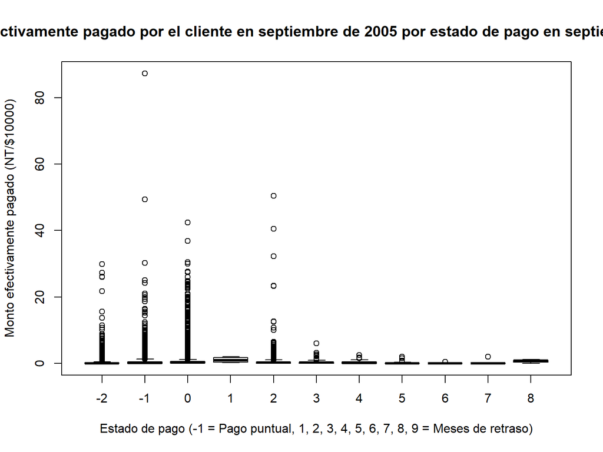

```r
boxplot(PAY_AMT1/10000 ~ PAY_3, data = datos_credit_visu,
        main = "Monto efectivamente pagado por el cliente en septiembre de 2005 por estado de pago en septiembre de 2005",
        xlab = "Estado de pago (-1 = Pago puntual, 1, 2, 3, 4, 5, 6, 7, 8, 9 = Meses de retraso)", ylab = "Monto efectivamente pagado (NT/$10000)",
        col = "grey90")
```

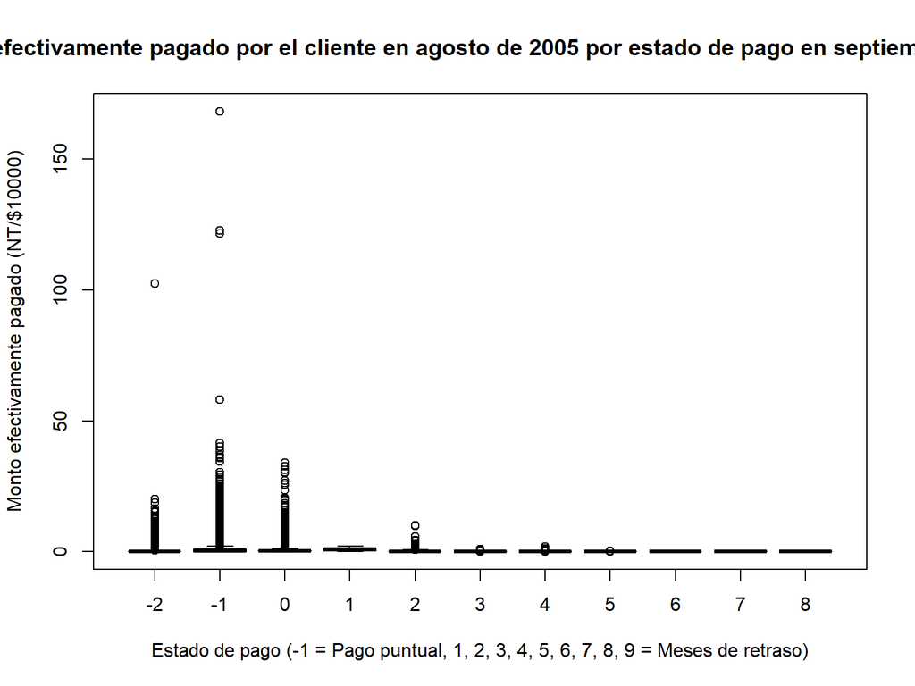

```r
boxplot(PAY_AMT2/10000 ~ PAY_3, data = datos_credit_visu,
        main = "Monto efectivamente pagado por el cliente en agosto de 2005 por estado de pago en septiembre de 2005",
        xlab = "Estado de pago (-1 = Pago puntual, 1, 2, 3, 4, 5, 6, 7, 8, 9 = Meses de retraso)", ylab = "Monto efectivamente pagado (NT/$10000)",
        col = "grey90")
```

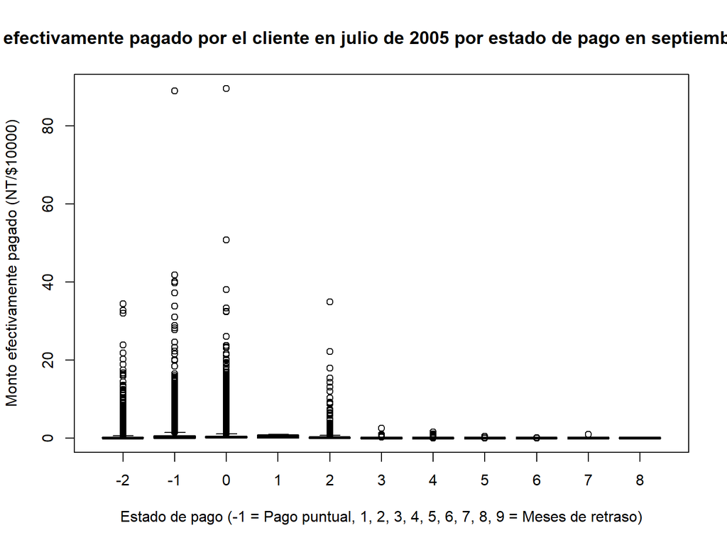

```r
boxplot(PAY_AMT3/10000 ~ PAY_3, data = datos_credit_visu,
        main = "Monto efectivamente pagado por el cliente en julio de 2005 por estado de pago en septiembre de 2005",
        xlab = "Estado de pago (-1 = Pago puntual, 1, 2, 3, 4, 5, 6, 7, 8, 9 = Meses de retraso)", ylab = "Monto efectivamente pagado (NT/$10000)",
        col = "grey90")
```

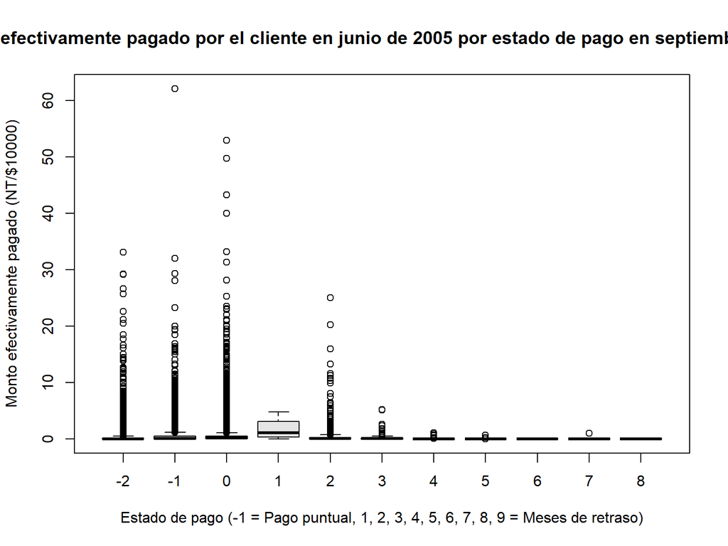

```r
boxplot(PAY_AMT4/10000 ~ PAY_3, data = datos_credit_visu,
        main = "Monto efectivamente pagado por el cliente en junio de 2005 por estado de pago en septiembre de 2005",
        xlab = "Estado de pago (-1 = Pago puntual, 1, 2, 3, 4, 5, 6, 7, 8, 9 = Meses de retraso)", ylab = "Monto efectivamente pagado (NT/$10000)",
        col = "grey90")
```

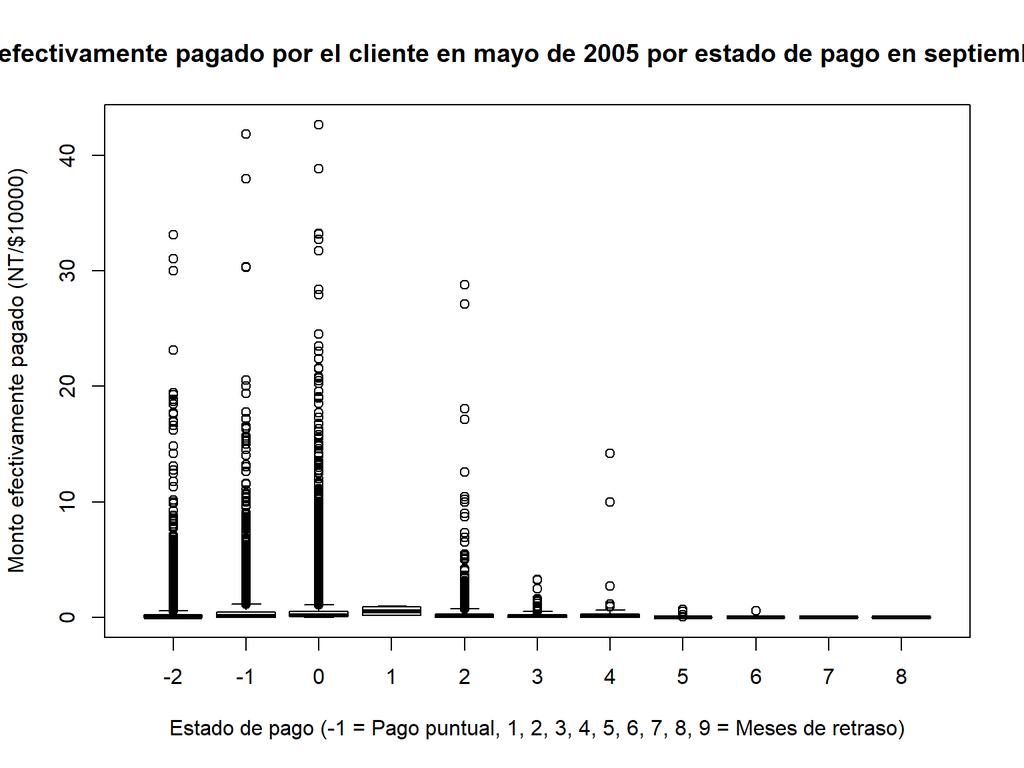

```r
boxplot(PAY_AMT5/10000 ~ PAY_3, data = datos_credit_visu,
        main = "Monto efectivamente pagado por el cliente en mayo de 2005 por estado de pago en septiembre de 2005",
        xlab = "Estado de pago (-1 = Pago puntual, 1, 2, 3, 4, 5, 6, 7, 8, 9 = Meses de retraso)", ylab = "Monto efectivamente pagado (NT/$10000)",
        col = "grey90")
```

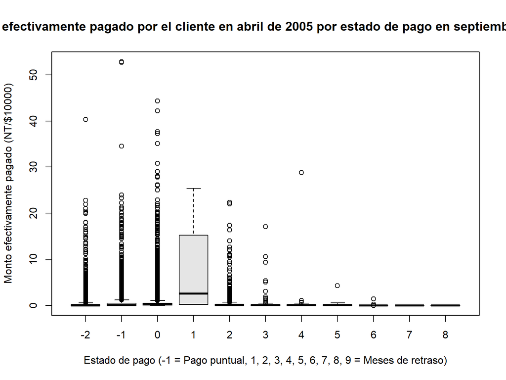

```r
boxplot(PAY_AMT6/10000 ~ PAY_3, data = datos_credit_visu,
        main = "Monto efectivamente pagado por el cliente en abril de 2005 por estado de pago en septiembre de 2005",
        xlab = "Estado de pago (-1 = Pago puntual, 1, 2, 3, 4, 5, 6, 7, 8, 9 = Meses de retraso)", ylab = "Monto efectivamente pagado (NT/$10000)",
        col = "grey90")
```

## 2.9 De PAY_4

En esta sección se cruza `PAY_4` (estado de pago del cliente en junio de 2005, convertida a factor) contra las mismas variables numéricas, siguiendo la misma lógica de las secciones anteriores de `PAY`.

Se cruza `LIMIT_BAL` contra `PAY_4`, para comparar el monto de crédito otorgado según el estado de pago de junio de 2005.

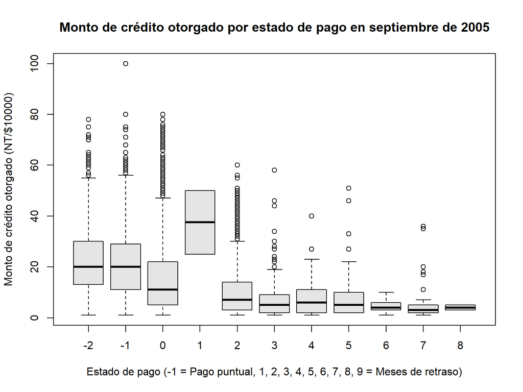

```r
boxplot(LIMIT_BAL/10000 ~ PAY_4, data = datos_credit_visu,
        main = "Monto de crédito otorgado por estado de pago en septiembre de 2005",
        xlab = "Estado de pago (-1 = Pago puntual, 1, 2, 3, 4, 5, 6, 7, 8, 9 = Meses de retraso)", ylab = "Monto de crédito otorgado (NT/$10000)",
        col = "grey90")
```

Se cruza `AGE` contra `PAY_4`, para observar si la edad se relaciona con el estado de pago de junio de 2005.

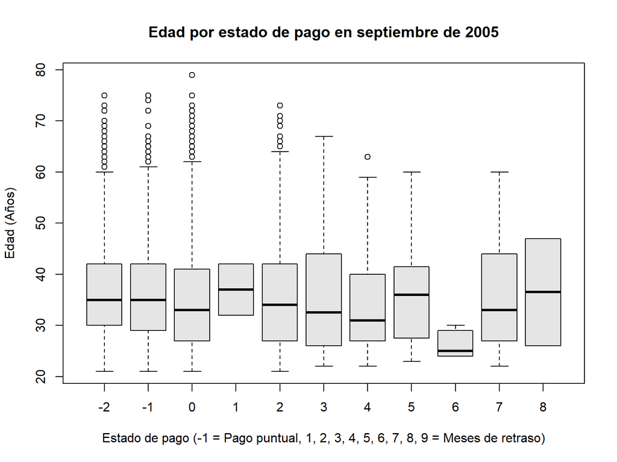

```r
boxplot(AGE ~ PAY_4, data = datos_credit_visu,
        main = "Edad por estado de pago en septiembre de 2005",
        xlab = "Estado de pago (-1 = Pago puntual, 1, 2, 3, 4, 5, 6, 7, 8, 9 = Meses de retraso)", ylab = "Edad (Años)",
        col = "grey90")
```

Se cruzan `BILL_AMT1` a `BILL_AMT6` contra `PAY_4`, generando un boxplot por mes para comparar el monto del estado de cuenta según el estado de pago de junio de 2005.

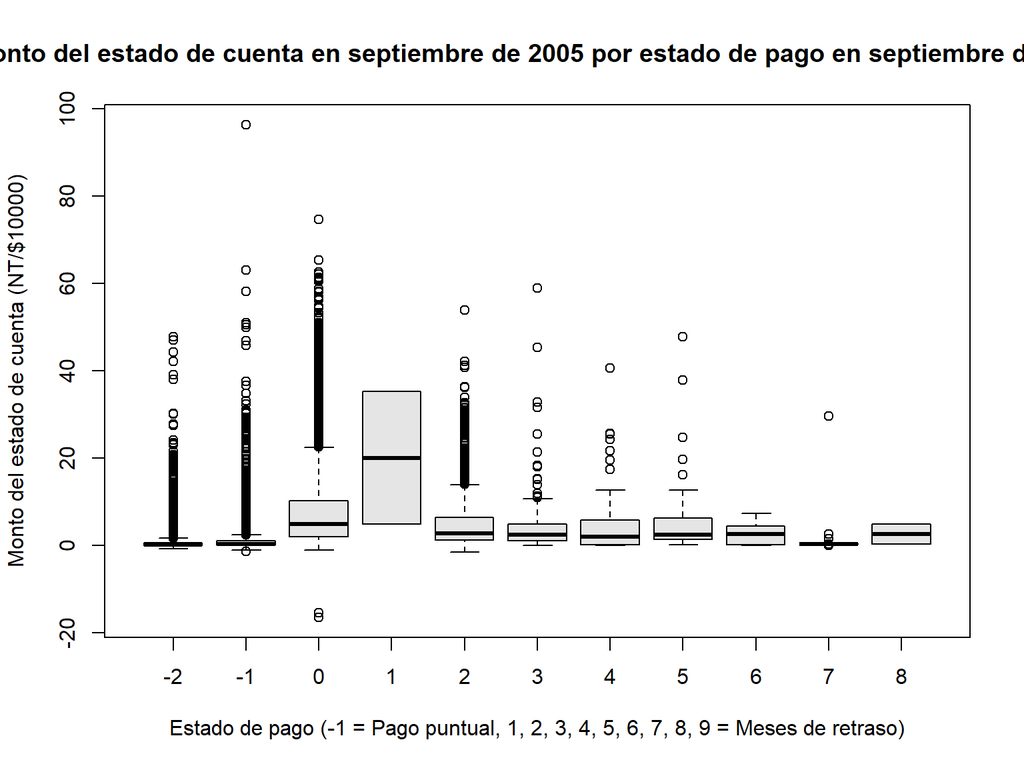

```r
boxplot(BILL_AMT1/10000 ~ PAY_4, data = datos_credit_visu,
        main = "Monto del estado de cuenta en septiembre de 2005 por estado de pago en septiembre de 2005",
        xlab = "Estado de pago (-1 = Pago puntual, 1, 2, 3, 4, 5, 6, 7, 8, 9 = Meses de retraso)", ylab = "Monto del estado de cuenta (NT/$10000)",
        col = "grey90")
```

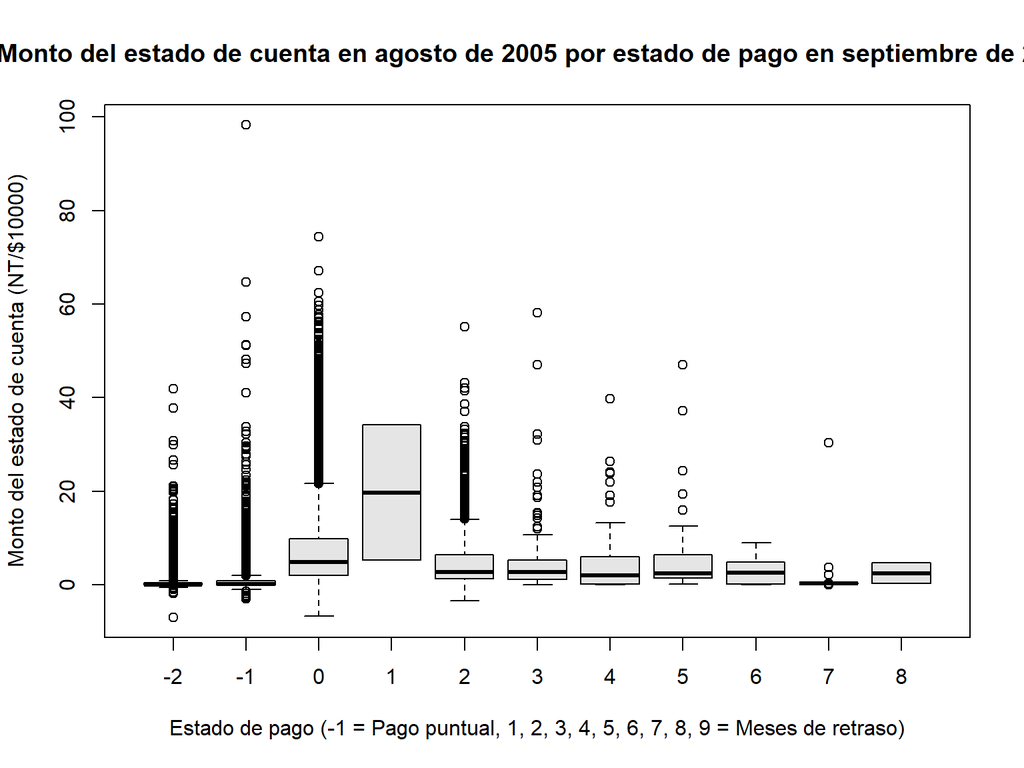

```r
boxplot(BILL_AMT2/10000 ~ PAY_4, data = datos_credit_visu,
        main = "Monto del estado de cuenta en agosto de 2005 por estado de pago en septiembre de 2005",
        xlab = "Estado de pago (-1 = Pago puntual, 1, 2, 3, 4, 5, 6, 7, 8, 9 = Meses de retraso)", ylab = "Monto del estado de cuenta (NT/$10000)",
        col = "grey90")
```

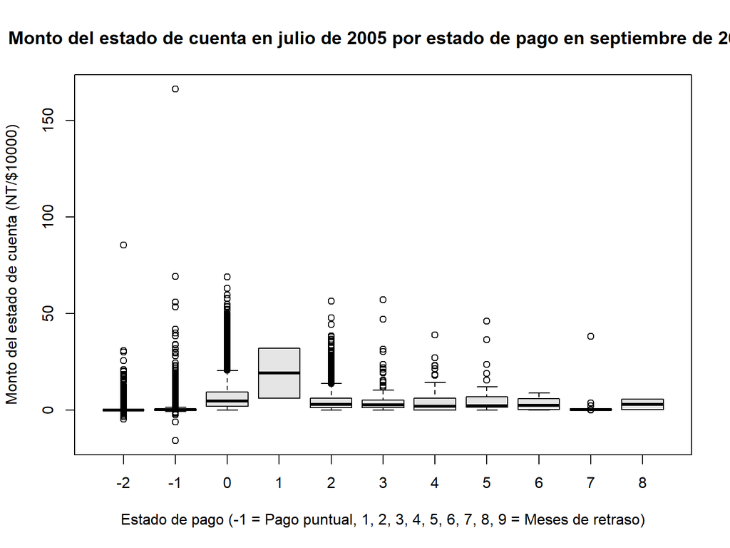

```r
boxplot(BILL_AMT3/10000 ~ PAY_4, data = datos_credit_visu,
        main = "Monto del estado de cuenta en julio de 2005 por estado de pago en septiembre de 2005",
        xlab = "Estado de pago (-1 = Pago puntual, 1, 2, 3, 4, 5, 6, 7, 8, 9 = Meses de retraso)", ylab = "Monto del estado de cuenta (NT/$10000)",
        col = "grey90")
```

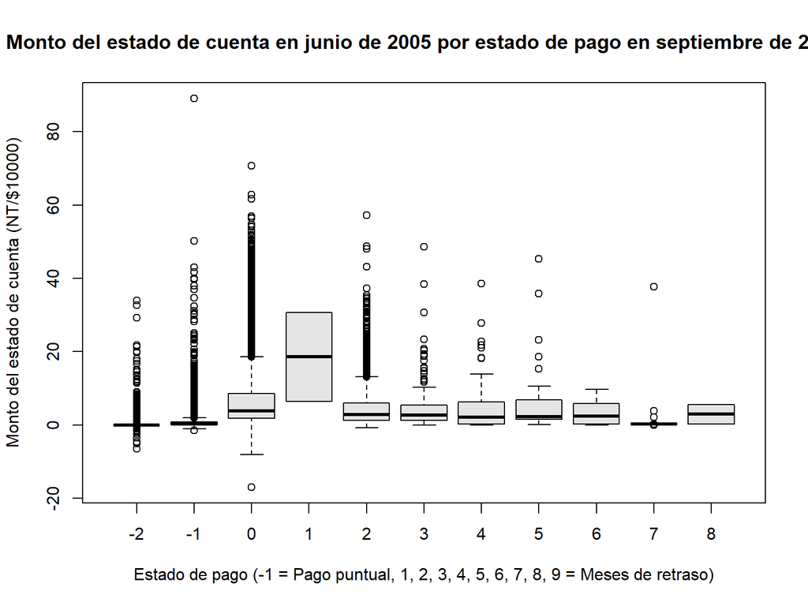

```r
boxplot(BILL_AMT4/10000 ~ PAY_4, data = datos_credit_visu,
        main = "Monto del estado de cuenta en junio de 2005 por estado de pago en septiembre de 2005",
        xlab = "Estado de pago (-1 = Pago puntual, 1, 2, 3, 4, 5, 6, 7, 8, 9 = Meses de retraso)", ylab = "Monto del estado de cuenta (NT/$10000)",
        col = "grey90")
```

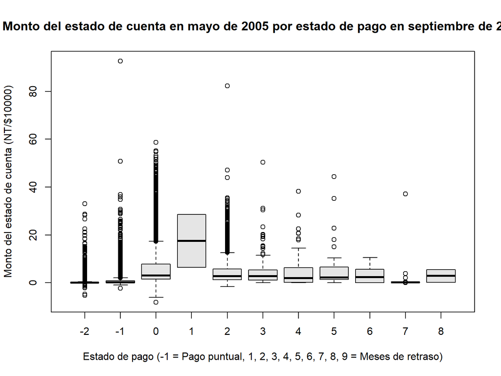

```r
boxplot(BILL_AMT5/10000 ~ PAY_4, data = datos_credit_visu,
        main = "Monto del estado de cuenta en mayo de 2005 por estado de pago en septiembre de 2005",
        xlab = "Estado de pago (-1 = Pago puntual, 1, 2, 3, 4, 5, 6, 7, 8, 9 = Meses de retraso)", ylab = "Monto del estado de cuenta (NT/$10000)",
        col = "grey90")
```

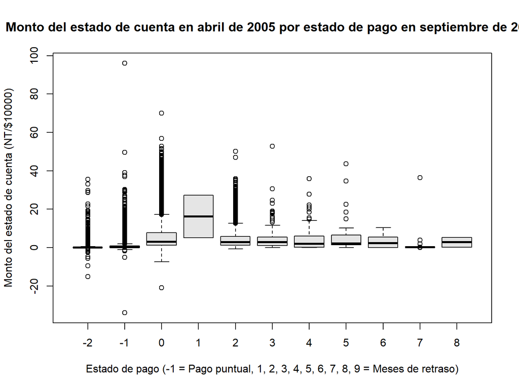

```r
boxplot(BILL_AMT6/10000 ~ PAY_4, data = datos_credit_visu,
        main = "Monto del estado de cuenta en abril de 2005 por estado de pago en septiembre de 2005",
        xlab = "Estado de pago (-1 = Pago puntual, 1, 2, 3, 4, 5, 6, 7, 8, 9 = Meses de retraso)", ylab = "Monto del estado de cuenta (NT/$10000)",
        col = "grey90")
```

Se cruzan `PAY_AMT1` a `PAY_AMT6` contra `PAY_4`, para comparar cuánto pagaron efectivamente los clientes según su estado de pago de junio de 2005, mes a mes.

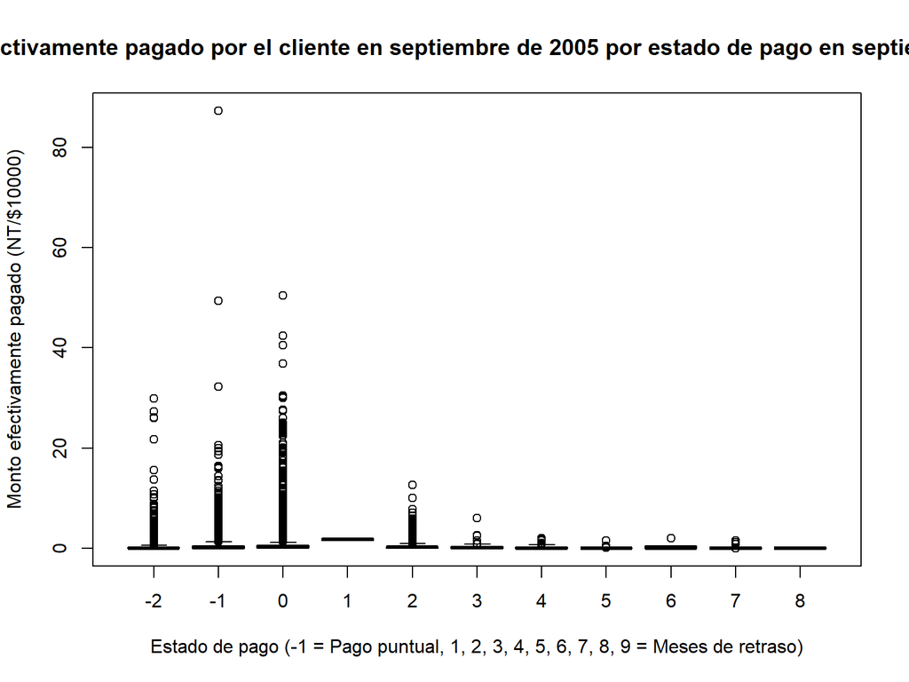

```r
boxplot(PAY_AMT1/10000 ~ PAY_4, data = datos_credit_visu,
        main = "Monto efectivamente pagado por el cliente en septiembre de 2005 por estado de pago en septiembre de 2005",
        xlab = "Estado de pago (-1 = Pago puntual, 1, 2, 3, 4, 5, 6, 7, 8, 9 = Meses de retraso)", ylab = "Monto efectivamente pagado (NT/$10000)",
        col = "grey90")
```

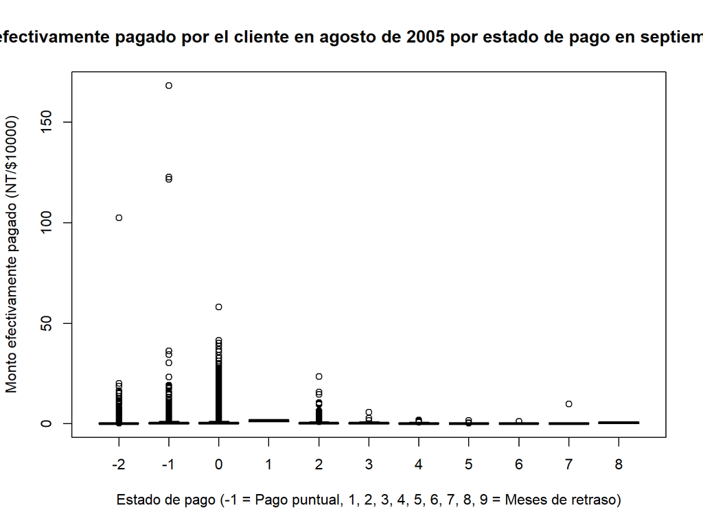

```r
boxplot(PAY_AMT2/10000 ~ PAY_4, data = datos_credit_visu,
        main = "Monto efectivamente pagado por el cliente en agosto de 2005 por estado de pago en septiembre de 2005",
        xlab = "Estado de pago (-1 = Pago puntual, 1, 2, 3, 4, 5, 6, 7, 8, 9 = Meses de retraso)", ylab = "Monto efectivamente pagado (NT/$10000)",
        col = "grey90")
```

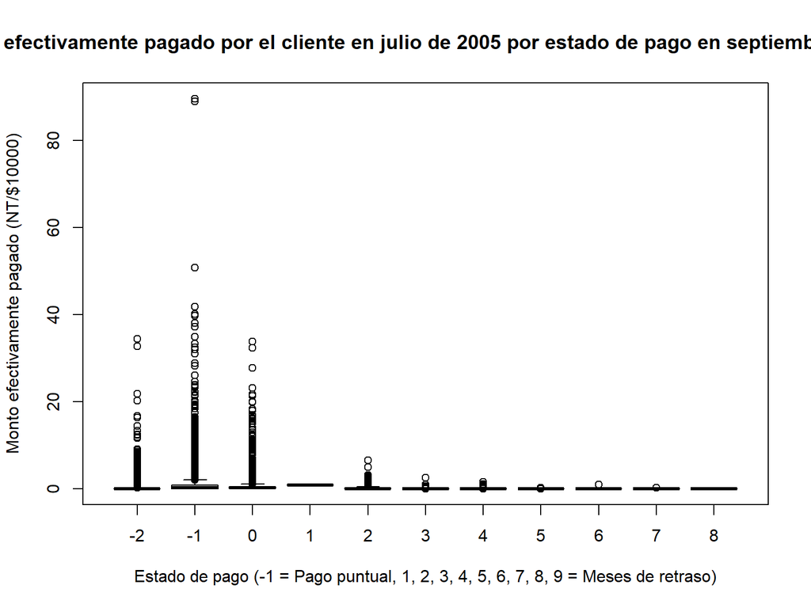

```r
boxplot(PAY_AMT3/10000 ~ PAY_4, data = datos_credit_visu,
        main = "Monto efectivamente pagado por el cliente en julio de 2005 por estado de pago en septiembre de 2005",
        xlab = "Estado de pago (-1 = Pago puntual, 1, 2, 3, 4, 5, 6, 7, 8, 9 = Meses de retraso)", ylab = "Monto efectivamente pagado (NT/$10000)",
        col = "grey90")
```

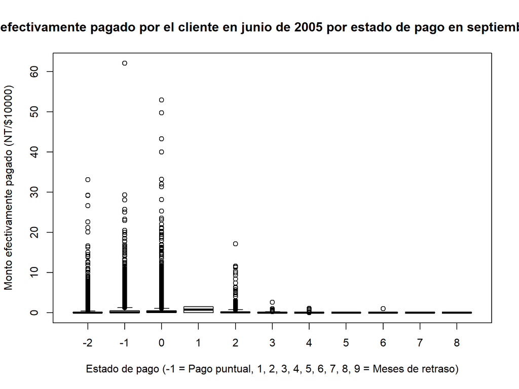

```r
boxplot(PAY_AMT4/10000 ~ PAY_4, data = datos_credit_visu,
        main = "Monto efectivamente pagado por el cliente en junio de 2005 por estado de pago en septiembre de 2005",
        xlab = "Estado de pago (-1 = Pago puntual, 1, 2, 3, 4, 5, 6, 7, 8, 9 = Meses de retraso)", ylab = "Monto efectivamente pagado (NT/$10000)",
        col = "grey90")
```

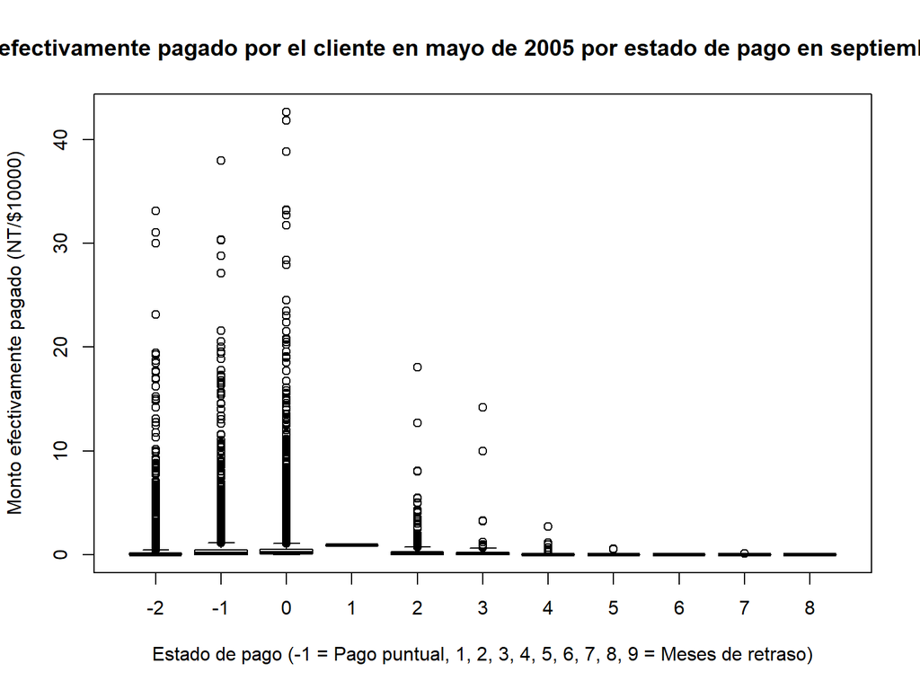

```r
boxplot(PAY_AMT5/10000 ~ PAY_4, data = datos_credit_visu,
        main = "Monto efectivamente pagado por el cliente en mayo de 2005 por estado de pago en septiembre de 2005",
        xlab = "Estado de pago (-1 = Pago puntual, 1, 2, 3, 4, 5, 6, 7, 8, 9 = Meses de retraso)", ylab = "Monto efectivamente pagado (NT/$10000)",
        col = "grey90")
```

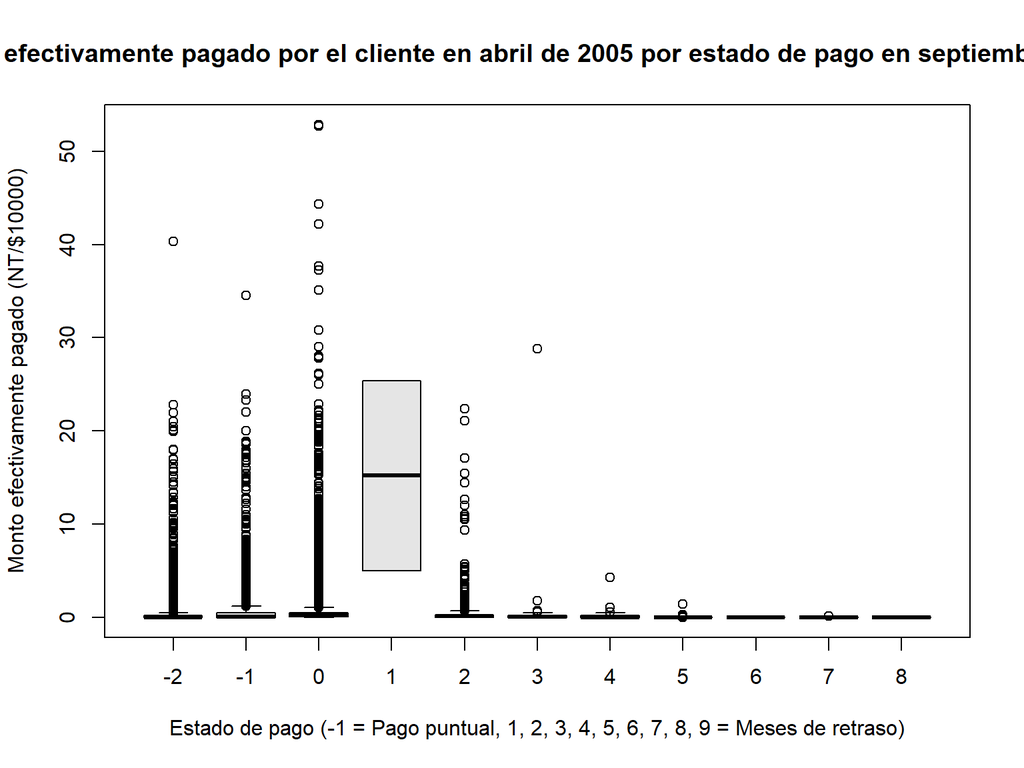

```r
boxplot(PAY_AMT6/10000 ~ PAY_4, data = datos_credit_visu,
        main = "Monto efectivamente pagado por el cliente en abril de 2005 por estado de pago en septiembre de 2005",
        xlab = "Estado de pago (-1 = Pago puntual, 1, 2, 3, 4, 5, 6, 7, 8, 9 = Meses de retraso)", ylab = "Monto efectivamente pagado (NT/$10000)",
        col = "grey90")
```

## 2.10 De PAY_5

En esta sección se cruza `PAY_5` (estado de pago del cliente en mayo de 2005, convertida a factor) contra las mismas variables numéricas, siguiendo la misma lógica de las secciones anteriores de `PAY`.

Se cruza `LIMIT_BAL` contra `PAY_5`, para comparar el monto de crédito otorgado según el estado de pago de mayo de 2005.

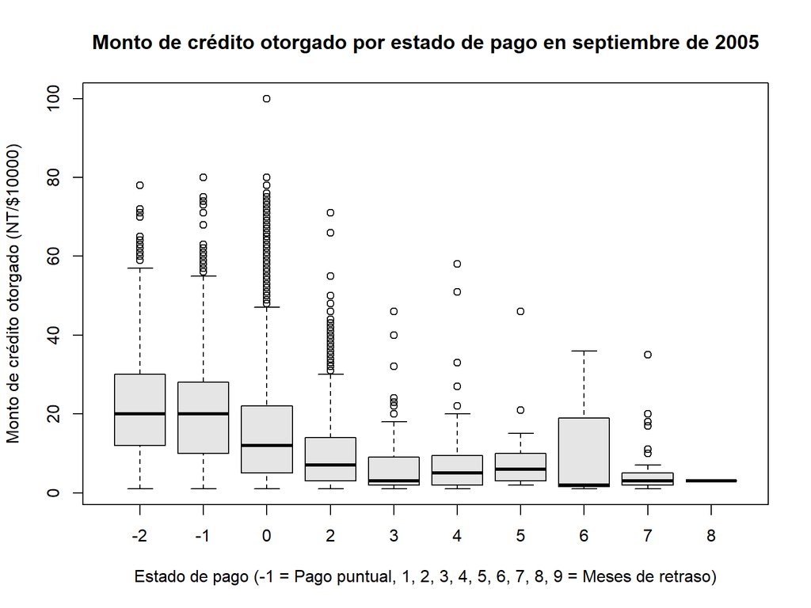

```r
boxplot(LIMIT_BAL/10000 ~ PAY_5, data = datos_credit_visu,
        main = "Monto de crédito otorgado por estado de pago en septiembre de 2005",
        xlab = "Estado de pago (-1 = Pago puntual, 1, 2, 3, 4, 5, 6, 7, 8, 9 = Meses de retraso)", ylab = "Monto de crédito otorgado (NT/$10000)",
        col = "grey90")
```

Se cruza `AGE` contra `PAY_5`, para observar si la edad se relaciona con el estado de pago de mayo de 2005.

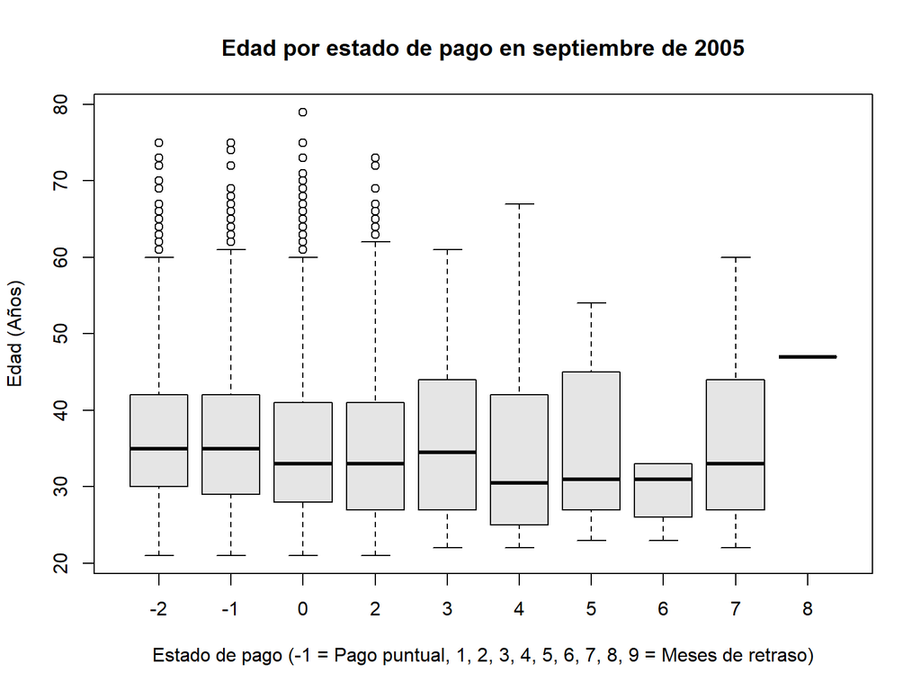

```r
boxplot(AGE ~ PAY_5, data = datos_credit_visu,
        main = "Edad por estado de pago en septiembre de 2005",
        xlab = "Estado de pago (-1 = Pago puntual, 1, 2, 3, 4, 5, 6, 7, 8, 9 = Meses de retraso)", ylab = "Edad (Años)",
        col = "grey90")
```

Se cruzan `BILL_AMT1` a `BILL_AMT6` contra `PAY_5`, generando un boxplot por mes para comparar el monto del estado de cuenta según el estado de pago de mayo de 2005.

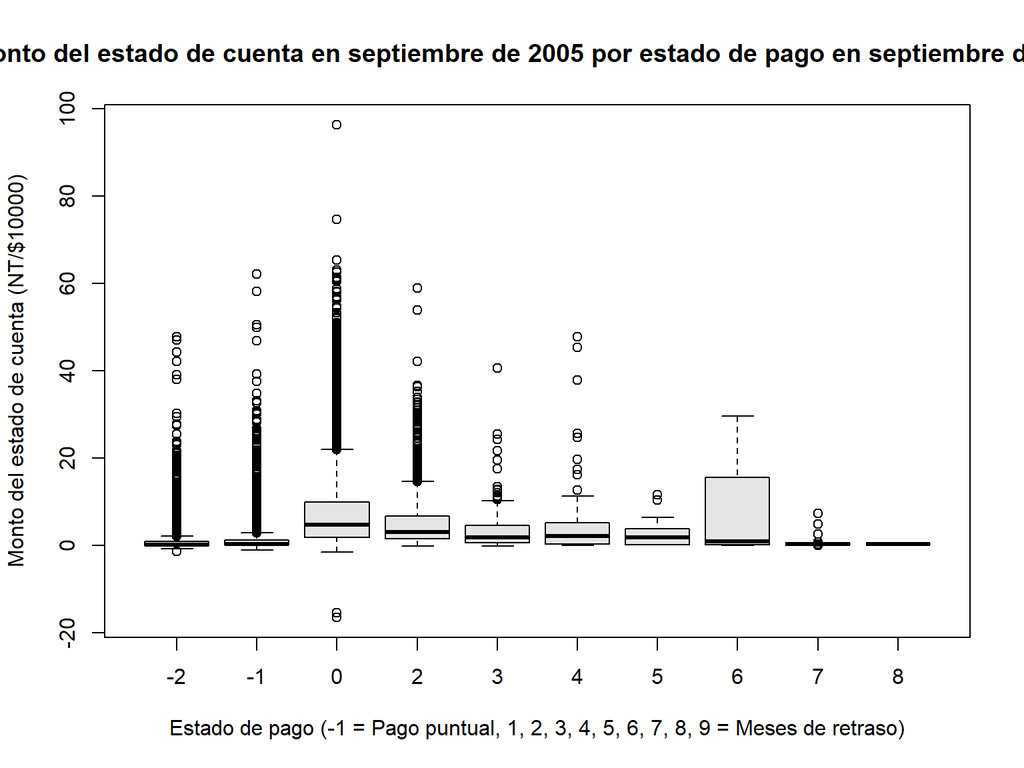

```r
boxplot(BILL_AMT1/10000 ~ PAY_5, data = datos_credit_visu,
        main = "Monto del estado de cuenta en septiembre de 2005 por estado de pago en septiembre de 2005",
        xlab = "Estado de pago (-1 = Pago puntual, 1, 2, 3, 4, 5, 6, 7, 8, 9 = Meses de retraso)", ylab = "Monto del estado de cuenta (NT/$10000)",
        col = "grey90")
```